# PORT analyses

Thomas McGregor

2024-06-14

# Explore

## Visualise missing data

- Should not be any missing data for variables derived from GLAD (i.e. age at screening & biological sex)
- Same goes for fear conditioning variables as missing data should be imputed (i.e. acquisition CS- and extinction CS+)

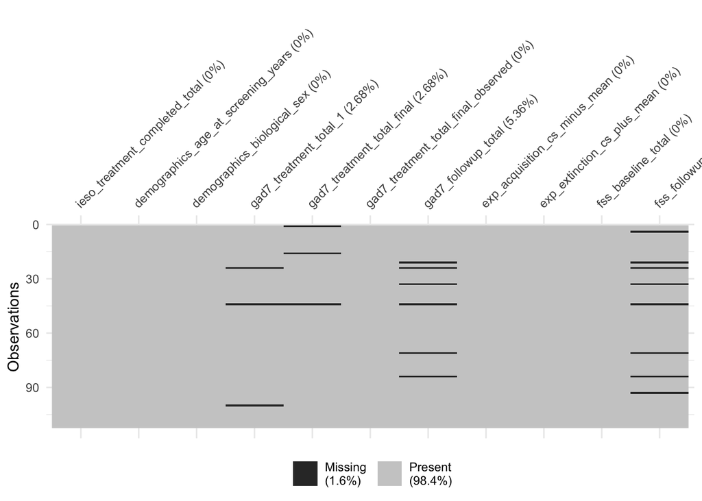

## Skew & kurtosis

Skewness and Kurtosis values all range between +/- 1.

```
## Descriptive Statistics
##
##                     demographics_age_at_screening_years   exp_acquisition_cs_minus_mean
## ----------------- ------------------------------------- -------------------------------
##              Mean                                 26.95                            4.16
##           Std.Dev                                  3.16                            1.11
##               Min                                 19.00                            1.48
##                Q1                                 25.00                            3.39
##            Median                                 27.00                            4.12
##                Q3                                 30.00                            4.87
##               Max                                 32.00                            7.87
##               MAD                                  2.97                            1.10
##               IQR                                  5.00                            1.48
##                CV                                  0.12                            0.27
##          Skewness                                 -0.45                            0.50
##       SE.Skewness                                  0.23                            0.23
##          Kurtosis                                 -0.51                            0.47
##           N.Valid                                112.00                          112.00
##         Pct.Valid                                100.00                          100.00
##
## Table: Table continues below
##
##
##
##                     exp_extinction_cs_plus_mean   fss_baseline_total   fss_followup_total
## ----------------- ----------------------------- -------------------- --------------------
##              Mean                          4.21               119.25               105.92
##           Std.Dev                          1.36                24.53                27.21
##               Min                          1.00                68.00                55.00
##                Q1                          3.55               103.00                83.50
##            Median                          4.05               118.00               100.00
##                Q3                          5.16               136.50               125.50
##               Max                          7.71               202.00               176.00
##               MAD                          1.27                24.46                29.65
##               IQR                          1.60                33.25                41.50
##                CV                          0.32                 0.21                 0.26
##          Skewness                         -0.11                 0.33                 0.45
##       SE.Skewness                          0.23                 0.23                 0.24
##          Kurtosis                         -0.04                 0.21                -0.72
##           N.Valid                        112.00               112.00               104.00
```

[output cut: 30 more lines]

```
##              Mean                                  8.09                             6.45
##           Std.Dev                                  4.87                             3.36
##               Min                                  0.00                             2.00
##                Q1                                  4.50                             4.00
##            Median                                  7.00                             6.00
##                Q3                                 11.00                             8.50
##               Max                                 21.00                            15.00
##               MAD                                  4.45                             2.97
##               IQR                                  6.25                             4.25
##                CV                                  0.60                             0.52
##          Skewness                                  0.88                             0.68
##       SE.Skewness                                  0.23                             0.23
##          Kurtosis                                 -0.05                            -0.27
##           N.Valid                                112.00                           112.00
##         Pct.Valid                                100.00                           100.00
```

## Correlations

### Acquisition CS- x GAD-7 at last session

#### Partial correlation

```
##      estimate   p.value  statistic   n gp  Method
## 1 -0.02343096 0.8170076 -0.2320184 101  1 pearson
```

#### Scatterplot

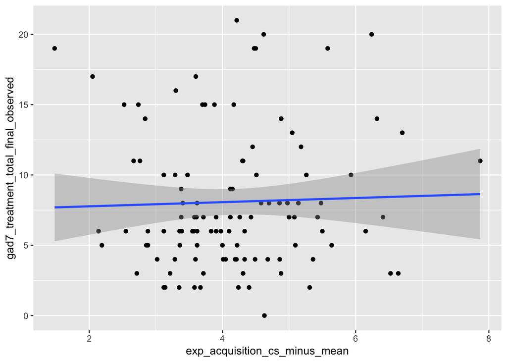

### Extinction CS+ x GAD-7 at last session

#### Partial correlation

```
##     estimate   p.value statistic   n gp  Method
## 1 0.06259379 0.5361302 0.6208644 101  1 pearson
```

#### Scatterplot

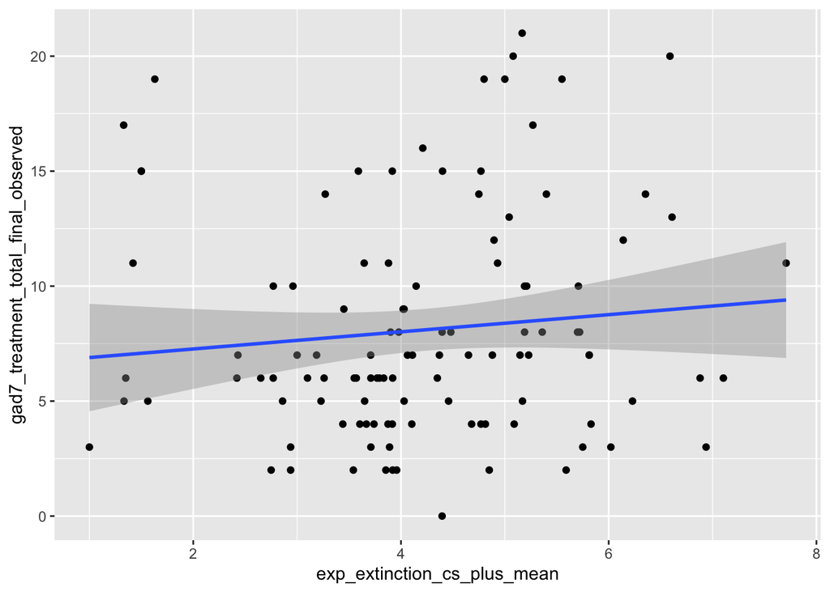

# Analyses

## Primary

### GAD-7 at last session

Primary analyses use fear conditioning expectancy ratings to predict last session GAD-7 scores while controlling for first session GAD-7 score and number of treatment sessions completed.

#### Acquisition CS-

```
##
## Call:
## lm(formula = gad7_treatment_total_final_observed ~ exp_acquisition_cs_minus_mean_z +
##     gad7_treatment_total_1_z + ieso_treatment_completed_total_z,
##     data = .)
##
## Residuals:
##     Min      1Q  Median      3Q     Max
## -9.7485 -2.2405 -0.2379  1.6190 10.4995
##
## Coefficients:
##                                  Estimate Std. Error t value Pr(>|t|)
## (Intercept)                        8.0810     0.3792  21.311  < 2e-16 ***
## exp_acquisition_cs_minus_mean_z   -0.2406     0.3818  -0.630  0.52990
## gad7_treatment_total_1_z           2.5265     0.3849   6.563 2.04e-09 ***
## ieso_treatment_completed_total_z  -1.5410     0.3833  -4.020  0.00011 ***
## ---
## Signif. codes:  0 '***' 0.001 '**' 0.01 '*' 0.05 '.' 0.1 ' ' 1
##
## Residual standard error: 3.958 on 105 degrees of freedom
##   (3 observations deleted due to missingness)
## Multiple R-squared:  0.3407, Adjusted R-squared:  0.3219
## F-statistic: 18.09 on 3 and 105 DF,  p-value: 1.551e-09
```

#### Extinction CS+

```
##
## Call:
## lm(formula = gad7_treatment_total_final_observed ~ exp_extinction_cs_plus_mean_z +
##     gad7_treatment_total_1_z + ieso_treatment_completed_total_z,
##     data = .)
##
## Residuals:
##      Min       1Q   Median       3Q      Max
## -10.2781  -2.0956  -0.3497   1.6547  10.3876
##
## Coefficients:
##                                  Estimate Std. Error t value Pr(>|t|)
## (Intercept)                       8.08047    0.37990  21.270  < 2e-16 ***
## exp_extinction_cs_plus_mean_z     0.02404    0.38353   0.063 0.950144
## gad7_treatment_total_1_z          2.49791    0.38588   6.473 3.14e-09 ***
## ieso_treatment_completed_total_z -1.51249    0.38677  -3.911 0.000164 ***
## ---
## Signif. codes:  0 '***' 0.001 '**' 0.01 '*' 0.05 '.' 0.1 ' ' 1
##
## Residual standard error: 3.965 on 105 degrees of freedom
##   (3 observations deleted due to missingness)
## Multiple R-squared:  0.3383, Adjusted R-squared:  0.3193
## F-statistic: 17.89 on 3 and 105 DF,  p-value: 1.88e-09
```

#### Combine

#### Plot

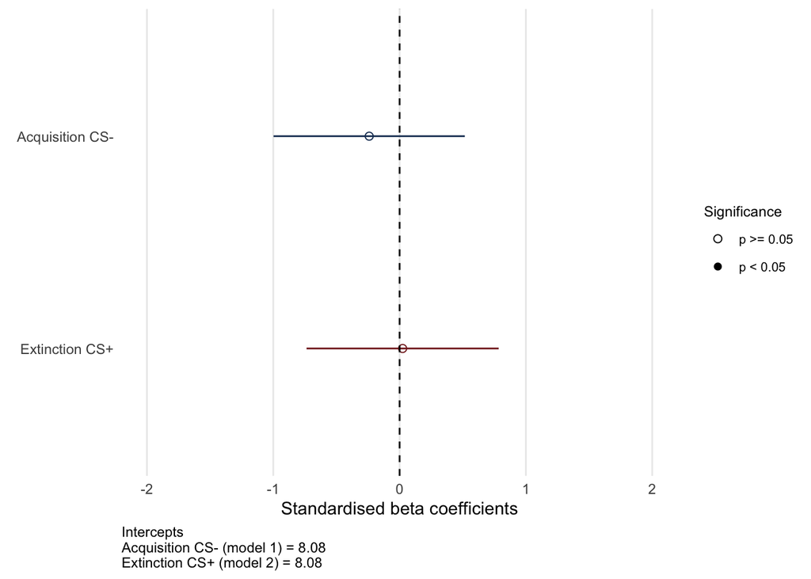

## Secondary

### Age/Sex adjustment

The first set of secondary analyses repeats the same models as the primary analyses, except age and sex are controlled for (included as covariates).

#### Acquisition CS-

```
##
## Call:
## lm(formula = gad7_treatment_total_final_observed ~ exp_acquisition_cs_minus_mean_z +
##     gad7_treatment_total_1_z + ieso_treatment_completed_total_z +
##     demographics_age_at_screening_years_z + demographics_biological_sex,
##     data = .)
##
## Residuals:
##     Min      1Q  Median      3Q     Max
## -9.3249 -2.2417 -0.5347  2.0229  9.8547
##
## Coefficients:
##                                       Estimate Std. Error t value Pr(>|t|)
## (Intercept)                             8.1777     0.3964  20.628  < 2e-16 ***
## exp_acquisition_cs_minus_mean_z        -0.1992     0.3807  -0.523    0.602
## gad7_treatment_total_1_z                2.4389     0.3866   6.309 7.15e-09 ***
## ieso_treatment_completed_total_z       -1.5951     0.3833  -4.161 6.57e-05 ***
## demographics_age_at_screening_years_z  -0.5845     0.3905  -1.497    0.138
## demographics_biological_sexmale        -0.9690     1.3211  -0.733    0.465
## ---
## Signif. codes:  0 '***' 0.001 '**' 0.01 '*' 0.05 '.' 0.1 ' ' 1
##
## Residual standard error: 3.938 on 103 degrees of freedom
##   (3 observations deleted due to missingness)
## Multiple R-squared:  0.3596, Adjusted R-squared:  0.3285
## F-statistic: 11.57 on 5 and 103 DF,  p-value: 7.027e-09
```

#### Extinction CS+

```
##
## Call:
## lm(formula = gad7_treatment_total_final_observed ~ exp_extinction_cs_plus_mean_z +
##     gad7_treatment_total_1_z + ieso_treatment_completed_total_z +
##     demographics_age_at_screening_years_z + demographics_biological_sex,
##     data = .)
##
## Residuals:
##     Min      1Q  Median      3Q     Max
## -9.4602 -2.2956 -0.5314  2.1190  9.7258
##
## Coefficients:
##                                       Estimate Std. Error t value Pr(>|t|)
## (Intercept)                            8.17818    0.39693  20.604  < 2e-16 ***
## exp_extinction_cs_plus_mean_z          0.05016    0.38171   0.131    0.896
## gad7_treatment_total_1_z               2.40981    0.38715   6.224 1.06e-08 ***
## ieso_treatment_completed_total_z      -1.56770    0.38651  -4.056 9.72e-05 ***
## demographics_age_at_screening_years_z -0.59935    0.39055  -1.535    0.128
## demographics_biological_sexmale       -0.97687    1.32271  -0.739    0.462
## ---
## Signif. codes:  0 '***' 0.001 '**' 0.01 '*' 0.05 '.' 0.1 ' ' 1
##
## Residual standard error: 3.943 on 103 degrees of freedom
##   (3 observations deleted due to missingness)
## Multiple R-squared:  0.358,  Adjusted R-squared:  0.3269
## F-statistic: 11.49 on 5 and 103 DF,  p-value: 7.937e-09
```

### GAD-7 at follow-up (DV)

The second set of secondary analyses repeats the same models as the primary analyses, except GAD-7 scores from follow-up are used as the outcome variable instead of GAD-7 scores from participants’ final treatment session.

#### Acquisition CS-

```
##
## Call:
## lm(formula = gad7_followup_total ~ exp_acquisition_cs_minus_mean_z +
##     gad7_treatment_total_1_z + ieso_treatment_completed_total_z,
##     data = .)
##
## Residuals:
##     Min      1Q  Median      3Q     Max
## -9.5837 -3.0987 -0.2571  2.0154 13.0797
##
## Coefficients:
##                                  Estimate Std. Error t value Pr(>|t|)
## (Intercept)                        7.5442     0.4075  18.516  < 2e-16 ***
## exp_acquisition_cs_minus_mean_z   -0.5717     0.4174  -1.370   0.1738
## gad7_treatment_total_1_z           2.5318     0.4113   6.156 1.52e-08 ***
## ieso_treatment_completed_total_z  -0.9178     0.4114  -2.231   0.0279 *
## ---
## Signif. codes:  0 '***' 0.001 '**' 0.01 '*' 0.05 '.' 0.1 ' ' 1
##
## Residual standard error: 4.167 on 101 degrees of freedom
##   (7 observations deleted due to missingness)
## Multiple R-squared:  0.2864, Adjusted R-squared:  0.2652
## F-statistic: 13.51 on 3 and 101 DF,  p-value: 1.758e-07
```

#### Extinction CS+

```
##
## Call:
## lm(formula = gad7_followup_total ~ exp_extinction_cs_plus_mean_z +
##     gad7_treatment_total_1_z + ieso_treatment_completed_total_z,
##     data = .)
##
## Residuals:
##     Min      1Q  Median      3Q     Max
## -9.9628 -3.0808 -0.1554  2.0180 13.0486
##
## Coefficients:
##                                  Estimate Std. Error t value Pr(>|t|)
## (Intercept)                        7.5407     0.4089  18.443  < 2e-16 ***
## exp_extinction_cs_plus_mean_z     -0.4466     0.4155  -1.075   0.2851
## gad7_treatment_total_1_z           2.5307     0.4135   6.121 1.79e-08 ***
## ieso_treatment_completed_total_z  -0.9312     0.4159  -2.239   0.0274 *
## ---
## Signif. codes:  0 '***' 0.001 '**' 0.01 '*' 0.05 '.' 0.1 ' ' 1
##
## Residual standard error: 4.182 on 101 degrees of freedom
##   (7 observations deleted due to missingness)
## Multiple R-squared:  0.2814, Adjusted R-squared:   0.26
## F-statistic: 13.18 on 3 and 101 DF,  p-value: 2.487e-07
```

### FSS scores at follow-up

The third set of secondary analyses repeats the same models as the primary analyses, except FSS scores from follow-up are used as the outcome variable instead of GAD-7 scores from participants’ final treatment session and FSS scores at baseline are controlled for instead of first treatment session GAD-7 scores.

#### Acquisition CS-

```
##
## Call:
## lm(formula = fss_followup_total ~ exp_acquisition_cs_minus_mean_z +
##     fss_baseline_total_z + ieso_treatment_completed_total_z,
##     data = .)
##
## Residuals:
##     Min      1Q  Median      3Q     Max
## -51.258 -12.932  -0.383   9.892  39.490
##
## Coefficients:
##                                  Estimate Std. Error t value Pr(>|t|)
## (Intercept)                      106.2893     1.8388  57.802   <2e-16 ***
## exp_acquisition_cs_minus_mean_z    0.8139     1.8781   0.433    0.666
## fss_baseline_total_z              21.2447     2.0114  10.562   <2e-16 ***
## ieso_treatment_completed_total_z  -0.1049     1.8607  -0.056    0.955
## ---
## Signif. codes:  0 '***' 0.001 '**' 0.01 '*' 0.05 '.' 0.1 ' ' 1
##
## Residual standard error: 18.72 on 100 degrees of freedom
##   (8 observations deleted due to missingness)
## Multiple R-squared:  0.5407, Adjusted R-squared:  0.527
## F-statistic: 39.25 on 3 and 100 DF,  p-value: < 2.2e-16
```

#### Extinction CS+

```
##
## Call:
## lm(formula = fss_followup_total ~ exp_extinction_cs_plus_mean_z +
##     fss_baseline_total_z + ieso_treatment_completed_total_z,
##     data = .)
##
## Residuals:
##     Min      1Q  Median      3Q     Max
## -51.078 -13.155  -0.164  10.082  39.521
##
## Coefficients:
##                                   Estimate Std. Error t value Pr(>|t|)
## (Intercept)                      106.29925    1.83958  57.785   <2e-16 ***
## exp_extinction_cs_plus_mean_z      0.55070    1.85965   0.296    0.768
## fss_baseline_total_z              21.28694    2.00852  10.598   <2e-16 ***
## ieso_treatment_completed_total_z  -0.09584    1.87159  -0.051    0.959
## ---
## Signif. codes:  0 '***' 0.001 '**' 0.01 '*' 0.05 '.' 0.1 ' ' 1
##
## Residual standard error: 18.73 on 100 degrees of freedom
##   (8 observations deleted due to missingness)
## Multiple R-squared:  0.5403, Adjusted R-squared:  0.5265
## F-statistic: 39.18 on 3 and 100 DF,  p-value: < 2.2e-16
```

### Combine

### Plot

Plots for secondary analyses not saved as they will not appear in the paper.

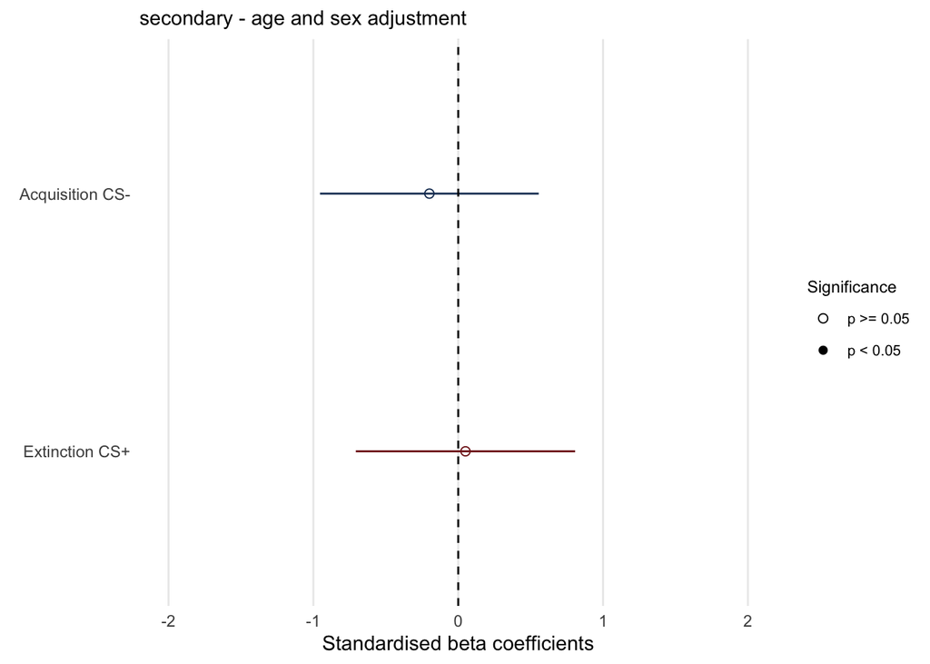

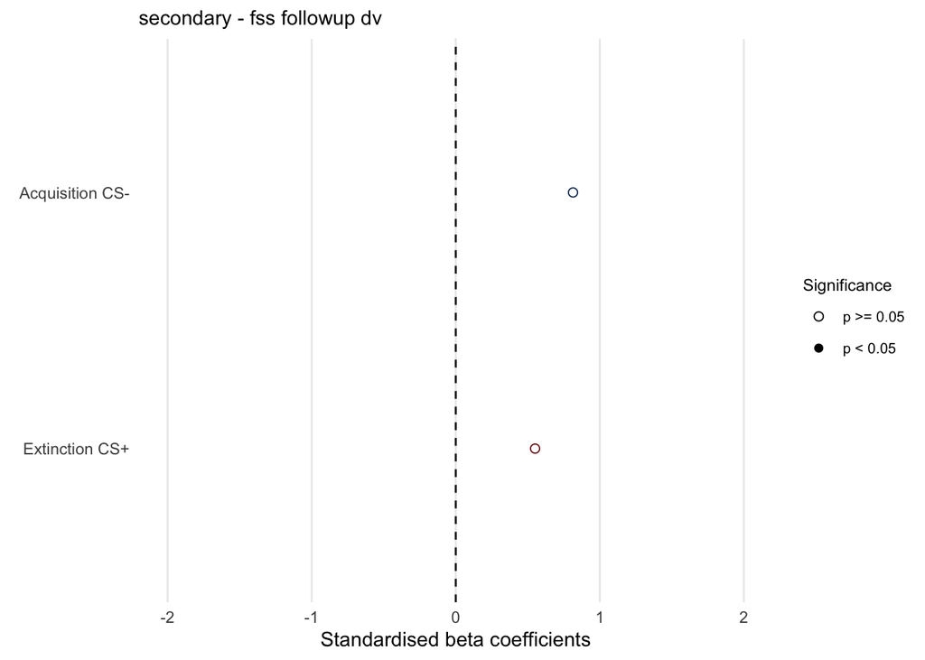

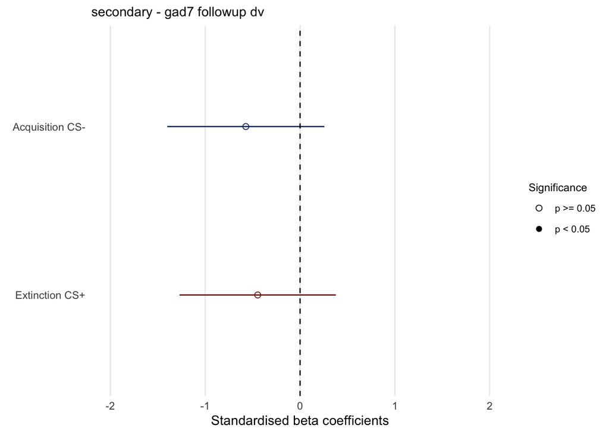

## Exploratory

### Discrimination scores (IV)

The first set of exploratory analyses use US-expectancy discrimination (CS+ minus CS-) scores to predict last session GAD-7 scores while controlling for first session GAD-7 score and number of treatment sessions completed.

#### Acquisition

```
##
## Call:
## lm(formula = gad7_treatment_total_final_observed ~ exp_acquisition_differential_mean_z +
##     gad7_treatment_total_1_z + ieso_treatment_completed_total_z,
##     data = .)
##
## Residuals:
##      Min       1Q   Median       3Q      Max
## -10.2377  -2.0342  -0.3091   1.6711  10.6718
##
## Coefficients:
##                                     Estimate Std. Error t value Pr(>|t|)
## (Intercept)                           8.0849     0.3792  21.320  < 2e-16 ***
## exp_acquisition_differential_mean_z   0.2583     0.3992   0.647 0.518999
## gad7_treatment_total_1_z              2.4548     0.3892   6.307 6.85e-09 ***
## ieso_treatment_completed_total_z     -1.4608     0.3907  -3.739 0.000302 ***
## ---
## Signif. codes:  0 '***' 0.001 '**' 0.01 '*' 0.05 '.' 0.1 ' ' 1
##
## Residual standard error: 3.957 on 105 degrees of freedom
##   (3 observations deleted due to missingness)
## Multiple R-squared:  0.3409, Adjusted R-squared:  0.322
## F-statistic:  18.1 on 3 and 105 DF,  p-value: 1.534e-09
```

#### Extinction

```
##
## Call:
## lm(formula = gad7_treatment_total_final_observed ~ exp_extinction_differential_mean_z +
##     gad7_treatment_total_1_z + ieso_treatment_completed_total_z,
##     data = .)
##
## Residuals:
##      Min       1Q   Median       3Q      Max
## -10.3020  -2.1246  -0.2984   1.7291  10.5110
##
## Coefficients:
##                                    Estimate Std. Error t value Pr(>|t|)
## (Intercept)                         8.07893    0.37989  21.267  < 2e-16 ***
## exp_extinction_differential_mean_z -0.08116    0.37967  -0.214 0.831138
## gad7_treatment_total_1_z            2.50162    0.38340   6.525 2.46e-09 ***
## ieso_treatment_completed_total_z   -1.50985    0.38310  -3.941 0.000146 ***
## ---
## Signif. codes:  0 '***' 0.001 '**' 0.01 '*' 0.05 '.' 0.1 ' ' 1
##
## Residual standard error: 3.964 on 105 degrees of freedom
##   (3 observations deleted due to missingness)
## Multiple R-squared:  0.3385, Adjusted R-squared:  0.3196
## F-statistic: 17.91 on 3 and 105 DF,  p-value: 1.842e-09
```

### Affective ratings (IV)

The second set of exploratory analyses use affective ratings to predict last session GAD-7 scores while controlling for first session GAD-7 score and number of treatment sessions completed.

#### Post-acquisition CS+

```
##
## Call:
## lm(formula = gad7_treatment_total_final_observed ~ aff_break_cs_plus_mean_z +
##     gad7_treatment_total_1_z + ieso_treatment_completed_total_z,
##     data = .)
##
## Residuals:
##      Min       1Q   Median       3Q      Max
## -10.2402  -2.1261  -0.3688   1.6472  10.4175
##
## Coefficients:
##                                  Estimate Std. Error t value Pr(>|t|)
## (Intercept)                        8.0807     0.3799  21.269  < 2e-16 ***
## aff_break_cs_plus_mean_z           0.0177     0.3831   0.046 0.963245
## gad7_treatment_total_1_z           2.4979     0.3881   6.436 3.73e-09 ***
## ieso_treatment_completed_total_z  -1.5164     0.3820  -3.970 0.000132 ***
## ---
## Signif. codes:  0 '***' 0.001 '**' 0.01 '*' 0.05 '.' 0.1 ' ' 1
##
## Residual standard error: 3.965 on 105 degrees of freedom
##   (3 observations deleted due to missingness)
## Multiple R-squared:  0.3382, Adjusted R-squared:  0.3193
## F-statistic: 17.89 on 3 and 105 DF,  p-value: 1.882e-09
```

#### Post-acquisition CS-

```
##
## Call:
## lm(formula = gad7_treatment_total_final_observed ~ aff_break_cs_minus_mean_z +
##     gad7_treatment_total_1_z + ieso_treatment_completed_total_z,
##     data = .)
##
## Residuals:
##      Min       1Q   Median       3Q      Max
## -10.2335  -2.0299  -0.2412   1.7998  10.4480
##
## Coefficients:
##                                  Estimate Std. Error t value Pr(>|t|)
## (Intercept)                        8.0807     0.3797  21.280  < 2e-16 ***
## aff_break_cs_minus_mean_z          0.1206     0.3876   0.311 0.756409
## gad7_treatment_total_1_z           2.4785     0.3898   6.358 5.41e-09 ***
## ieso_treatment_completed_total_z  -1.5053     0.3834  -3.926 0.000155 ***
## ---
## Signif. codes:  0 '***' 0.001 '**' 0.01 '*' 0.05 '.' 0.1 ' ' 1
##
## Residual standard error: 3.963 on 105 degrees of freedom
##   (3 observations deleted due to missingness)
## Multiple R-squared:  0.3388, Adjusted R-squared:  0.3199
## F-statistic: 17.94 on 3 and 105 DF,  p-value: 1.797e-09
```

#### Post-extinction CS+

```
##
## Call:
## lm(formula = gad7_treatment_total_final_observed ~ aff_post_cs_plus_mean_z +
##     gad7_treatment_total_1_z + ieso_treatment_completed_total_z,
##     data = .)
##
## Residuals:
##      Min       1Q   Median       3Q      Max
## -10.1325  -1.9691  -0.3502   1.6155  10.7137
##
## Coefficients:
##                                  Estimate Std. Error t value Pr(>|t|)
## (Intercept)                        8.0778     0.3795  21.287  < 2e-16 ***
## aff_post_cs_plus_mean_z            0.2072     0.4070   0.509 0.611804
## gad7_treatment_total_1_z           2.4461     0.3977   6.151 1.42e-08 ***
## ieso_treatment_completed_total_z  -1.4854     0.3863  -3.845 0.000207 ***
## ---
## Signif. codes:  0 '***' 0.001 '**' 0.01 '*' 0.05 '.' 0.1 ' ' 1
##
## Residual standard error: 3.96 on 105 degrees of freedom
##   (3 observations deleted due to missingness)
## Multiple R-squared:  0.3399, Adjusted R-squared:  0.321
## F-statistic: 18.02 on 3 and 105 DF,  p-value: 1.659e-09
```

#### Post-extinction CS-

```
##
## Call:
## lm(formula = gad7_treatment_total_final_observed ~ aff_post_cs_minus_mean_z +
##     gad7_treatment_total_1_z + ieso_treatment_completed_total_z,
##     data = .)
##
## Residuals:
##      Min       1Q   Median       3Q      Max
## -10.2059  -2.1417  -0.3336   1.8426  10.4124
##
## Coefficients:
##                                  Estimate Std. Error t value Pr(>|t|)
## (Intercept)                        8.0748     0.3777  21.382  < 2e-16 ***
## aff_post_cs_minus_mean_z           0.4292     0.3801   1.129 0.261329
## gad7_treatment_total_1_z           2.5225     0.3816   6.610 1.64e-09 ***
## ieso_treatment_completed_total_z  -1.4851     0.3807  -3.901 0.000169 ***
## ---
## Signif. codes:  0 '***' 0.001 '**' 0.01 '*' 0.05 '.' 0.1 ' ' 1
##
## Residual standard error: 3.941 on 105 degrees of freedom
##   (3 observations deleted due to missingness)
## Multiple R-squared:  0.3462, Adjusted R-squared:  0.3275
## F-statistic: 18.53 on 3 and 105 DF,  p-value: 1.011e-09
```

### Non-fear conditioning (IVs)

The third set of exploratory analyses uses anxiety-related variables to predict last session GAD-7 scores while controlling for first session GAD-7 score and number of treatment sessions completed.

#### ASI

```
##
## Call:
## lm(formula = gad7_treatment_total_final_observed ~ asi_baseline_total_z +
##     gad7_treatment_total_1_z + ieso_treatment_completed_total_z,
##     data = .)
##
## Residuals:
##      Min       1Q   Median       3Q      Max
## -10.2548  -2.1210  -0.3447   1.6619  10.3866
##
## Coefficients:
##                                  Estimate Std. Error t value Pr(>|t|)
## (Intercept)                       8.08037    0.37991  21.269  < 2e-16 ***
## asi_baseline_total_z              0.01334    0.39753   0.034 0.973303
## gad7_treatment_total_1_z          2.49660    0.40178   6.214 1.06e-08 ***
## ieso_treatment_completed_total_z -1.51580    0.38227  -3.965 0.000134 ***
## ---
## Signif. codes:  0 '***' 0.001 '**' 0.01 '*' 0.05 '.' 0.1 ' ' 1
##
## Residual standard error: 3.965 on 105 degrees of freedom
##   (3 observations deleted due to missingness)
## Multiple R-squared:  0.3382, Adjusted R-squared:  0.3193
## F-statistic: 17.89 on 3 and 105 DF,  p-value: 1.883e-09
```

#### CBAS

```
##
## Call:
## lm(formula = gad7_treatment_total_final_observed ~ cbas_baseline_total_z +
##     gad7_treatment_total_1_z + ieso_treatment_completed_total_z,
##     data = .)
##
## Residuals:
##      Min       1Q   Median       3Q      Max
## -10.5876  -2.1933  -0.3441   1.6799  10.3343
##
## Coefficients:
##                                  Estimate Std. Error t value Pr(>|t|)
## (Intercept)                        8.0840     0.3797  21.293  < 2e-16 ***
## cbas_baseline_total_z              0.1804     0.4196   0.430  0.66803
## gad7_treatment_total_1_z           2.4298     0.4170   5.826 6.28e-08 ***
## ieso_treatment_completed_total_z  -1.5098     0.3820  -3.953  0.00014 ***
## ---
## Signif. codes:  0 '***' 0.001 '**' 0.01 '*' 0.05 '.' 0.1 ' ' 1
##
## Residual standard error: 3.962 on 105 degrees of freedom
##   (3 observations deleted due to missingness)
## Multiple R-squared:  0.3394, Adjusted R-squared:  0.3205
## F-statistic: 17.98 on 3 and 105 DF,  p-value: 1.721e-09
```

#### eACS

```
##
## Call:
## lm(formula = gad7_treatment_total_final_observed ~ eacs_midapp_total_z +
##     gad7_treatment_total_1_z + ieso_treatment_completed_total_z,
##     data = .)
##
## Residuals:
##      Min       1Q   Median       3Q      Max
## -10.0315  -2.1456  -0.3186   1.6711  10.5764
##
## Coefficients:
##                                  Estimate Std. Error t value Pr(>|t|)
## (Intercept)                        8.0783     0.3798  21.270  < 2e-16 ***
## eacs_midapp_total_z               -0.1319     0.4235  -0.312 0.756027
## gad7_treatment_total_1_z           2.4420     0.4270   5.719 1.02e-07 ***
## ieso_treatment_completed_total_z  -1.5058     0.3833  -3.929 0.000153 ***
## ---
## Signif. codes:  0 '***' 0.001 '**' 0.01 '*' 0.05 '.' 0.1 ' ' 1
##
## Residual standard error: 3.963 on 105 degrees of freedom
##   (3 observations deleted due to missingness)
## Multiple R-squared:  0.3388, Adjusted R-squared:   0.32
## F-statistic: 17.94 on 3 and 105 DF,  p-value: 1.796e-09
```

### Depression (covariate)

The fourth set of exploratory analyses repeats the primary analyses while additionally adjusting for depression symptoms.

#### Acquisition CS-

```
##
## Call:
## lm(formula = gad7_treatment_total_final_observed ~ exp_acquisition_cs_minus_mean_z +
##     gad7_treatment_total_1_z + ieso_treatment_completed_total_z +
##     phq9_treatment_total_1_z, data = .)
##
## Residuals:
##     Min      1Q  Median      3Q     Max
## -9.9679 -2.5542 -0.1898  2.2068 10.0612
##
## Coefficients:
##                                  Estimate Std. Error t value Pr(>|t|)
## (Intercept)                        8.0808     0.3645  22.171  < 2e-16 ***
## exp_acquisition_cs_minus_mean_z   -0.4173     0.3713  -1.124 0.263717
## gad7_treatment_total_1_z           1.6977     0.4561   3.722 0.000321 ***
## ieso_treatment_completed_total_z  -1.5289     0.3684  -4.150 6.82e-05 ***
## phq9_treatment_total_1_z           1.4280     0.4596   3.107 0.002438 **
## ---
## Signif. codes:  0 '***' 0.001 '**' 0.01 '*' 0.05 '.' 0.1 ' ' 1
##
## Residual standard error: 3.804 on 104 degrees of freedom
##   (3 observations deleted due to missingness)
## Multiple R-squared:  0.3967, Adjusted R-squared:  0.3735
## F-statistic:  17.1 on 4 and 104 DF,  p-value: 8.358e-11
```

#### Extinction CS+

```
##
## Call:
## lm(formula = gad7_treatment_total_final_observed ~ exp_extinction_cs_plus_mean_z +
##     gad7_treatment_total_1_z + ieso_treatment_completed_total_z +
##     phq9_treatment_total_1_z, data = .)
##
## Residuals:
##     Min      1Q  Median      3Q     Max
## -10.618  -2.260  -0.270   2.072   9.619
##
## Coefficients:
##                                  Estimate Std. Error t value Pr(>|t|)
## (Intercept)                       8.07955    0.36656  22.041  < 2e-16 ***
## exp_extinction_cs_plus_mean_z    -0.09357    0.37219  -0.251 0.801999
## gad7_treatment_total_1_z          1.70295    0.45894   3.711 0.000334 ***
## ieso_treatment_completed_total_z -1.50226    0.37321  -4.025 0.000108 ***
## phq9_treatment_total_1_z          1.36122    0.45943   2.963 0.003778 **
## ---
## Signif. codes:  0 '***' 0.001 '**' 0.01 '*' 0.05 '.' 0.1 ' ' 1
##
## Residual standard error: 3.826 on 104 degrees of freedom
##   (3 observations deleted due to missingness)
## Multiple R-squared:  0.3898, Adjusted R-squared:  0.3663
## F-statistic: 16.61 on 4 and 104 DF,  p-value: 1.491e-10
```

### Low GAD-7 excluded

The fifth set of exploratory analyses repeats those from the primary analyses with participants excluded if their GAD-7 score is lower than eight on their first treatment session.

#### Acquisition CS-

```
##
## Call:
## lm(formula = gad7_treatment_total_final_observed ~ exp_acquisition_cs_minus_mean_z +
##     gad7_treatment_total_1_z + ieso_treatment_completed_total_z,
##     data = .)
##
## Residuals:
##     Min      1Q  Median      3Q     Max
## -9.5871 -2.3376 -0.2135  1.8881 10.5526
##
## Coefficients:
##                                  Estimate Std. Error t value Pr(>|t|)
## (Intercept)                        8.1297     0.4296  18.923  < 2e-16 ***
## exp_acquisition_cs_minus_mean_z   -0.2840     0.4076  -0.697 0.487683
## gad7_treatment_total_1_z           2.4749     0.5044   4.906 3.88e-06 ***
## ieso_treatment_completed_total_z  -1.5485     0.4073  -3.802 0.000255 ***
## ---
## Signif. codes:  0 '***' 0.001 '**' 0.01 '*' 0.05 '.' 0.1 ' ' 1
##
## Residual standard error: 4.132 on 94 degrees of freedom
## Multiple R-squared:  0.2805, Adjusted R-squared:  0.2576
## F-statistic: 12.22 on 3 and 94 DF,  p-value: 8.064e-07
```

#### Extinction CS+

```
##
## Call:
## lm(formula = gad7_treatment_total_final_observed ~ exp_extinction_cs_plus_mean_z +
##     gad7_treatment_total_1_z + ieso_treatment_completed_total_z,
##     data = .)
##
## Residuals:
##      Min       1Q   Median       3Q      Max
## -10.0860  -2.4219  -0.3759   1.9232  10.4697
##
## Coefficients:
##                                  Estimate Std. Error t value Pr(>|t|)
## (Intercept)                        8.1279     0.4307  18.871  < 2e-16 ***
## exp_extinction_cs_plus_mean_z     -0.0415     0.4191  -0.099 0.921336
## gad7_treatment_total_1_z           2.4488     0.5069   4.831 5.26e-06 ***
## ieso_treatment_completed_total_z  -1.5252     0.4123  -3.699 0.000364 ***
## ---
## Signif. codes:  0 '***' 0.001 '**' 0.01 '*' 0.05 '.' 0.1 ' ' 1
##
## Residual standard error: 4.142 on 94 degrees of freedom
## Multiple R-squared:  0.2769, Adjusted R-squared:  0.2538
## F-statistic:    12 on 3 and 94 DF,  p-value: 1.016e-06
```

### Non-completers excluded

The sixth set of exploratory analyses repeats those from the primary analyses with participants excluded if they were not classified as treatment completers.

#### Acquisition CS-

```
##
## Call:
## lm(formula = gad7_treatment_total_final_observed ~ exp_acquisition_cs_minus_mean_z +
##     gad7_treatment_total_1_z + ieso_treatment_completed_total_z,
##     data = .)
##
## Residuals:
##     Min      1Q  Median      3Q     Max
## -6.9579 -2.3066 -0.4004  1.1067 11.1648
##
## Coefficients:
##                                  Estimate Std. Error t value Pr(>|t|)
## (Intercept)                        6.7788     0.4433  15.291  < 2e-16 ***
## exp_acquisition_cs_minus_mean_z   -0.3336     0.4595  -0.726    0.470
## gad7_treatment_total_1_z           1.8413     0.4434   4.153 8.51e-05 ***
## ieso_treatment_completed_total_z  -0.3214     0.4515  -0.712    0.479
## ---
## Signif. codes:  0 '***' 0.001 '**' 0.01 '*' 0.05 '.' 0.1 ' ' 1
##
## Residual standard error: 3.724 on 76 degrees of freedom
##   (1 observation deleted due to missingness)
## Multiple R-squared:  0.1866, Adjusted R-squared:  0.1545
## F-statistic: 5.812 on 3 and 76 DF,  p-value: 0.001247
```

#### Extinction CS+

```
##
## Call:
## lm(formula = gad7_treatment_total_final_observed ~ exp_extinction_cs_plus_mean_z +
##     gad7_treatment_total_1_z + ieso_treatment_completed_total_z,
##     data = .)
##
## Residuals:
##     Min      1Q  Median      3Q     Max
## -7.2724 -2.2973 -0.4897  0.9760 11.1733
##
## Coefficients:
##                                  Estimate Std. Error t value Pr(>|t|)
## (Intercept)                        6.7827     0.4449  15.245  < 2e-16 ***
## exp_extinction_cs_plus_mean_z     -0.2130     0.4271  -0.499    0.619
## gad7_treatment_total_1_z           1.8369     0.4447   4.131  9.2e-05 ***
## ieso_treatment_completed_total_z  -0.3266     0.4524  -0.722    0.473
## ---
## Signif. codes:  0 '***' 0.001 '**' 0.01 '*' 0.05 '.' 0.1 ' ' 1
##
## Residual standard error: 3.73 on 76 degrees of freedom
##   (1 observation deleted due to missingness)
## Multiple R-squared:  0.1836, Adjusted R-squared:  0.1514
## F-statistic: 5.699 on 3 and 76 DF,  p-value: 0.001422
```

### Combine

### Plot

Plots for secondary analyses not saved as they will not appear in the paper.

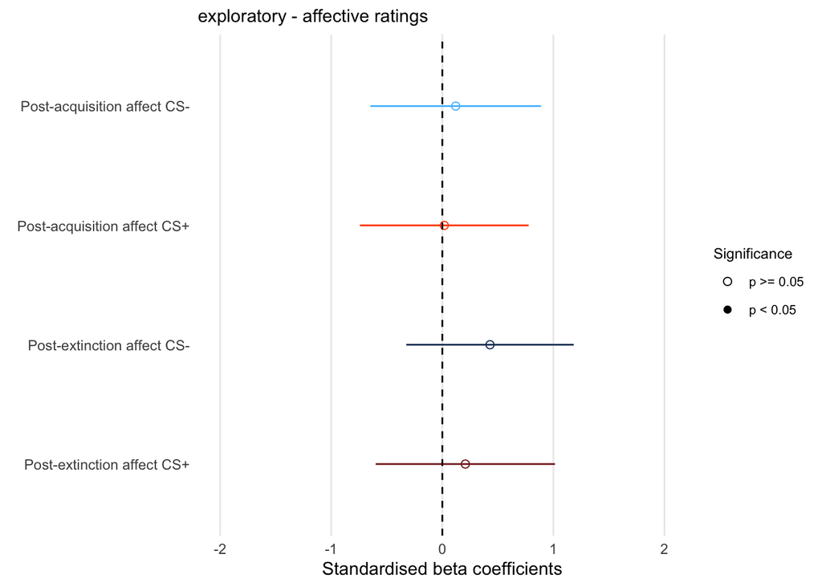

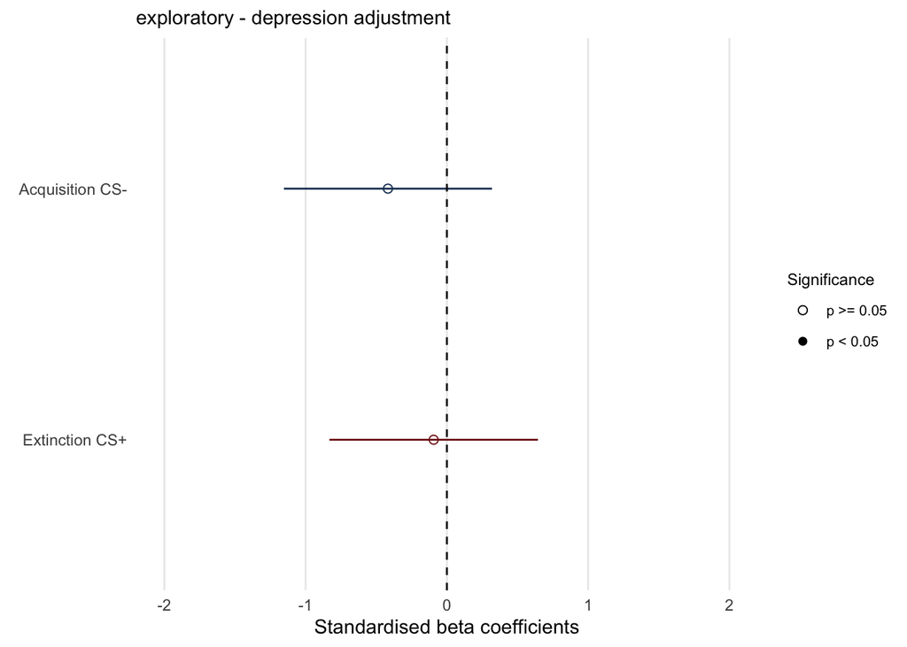

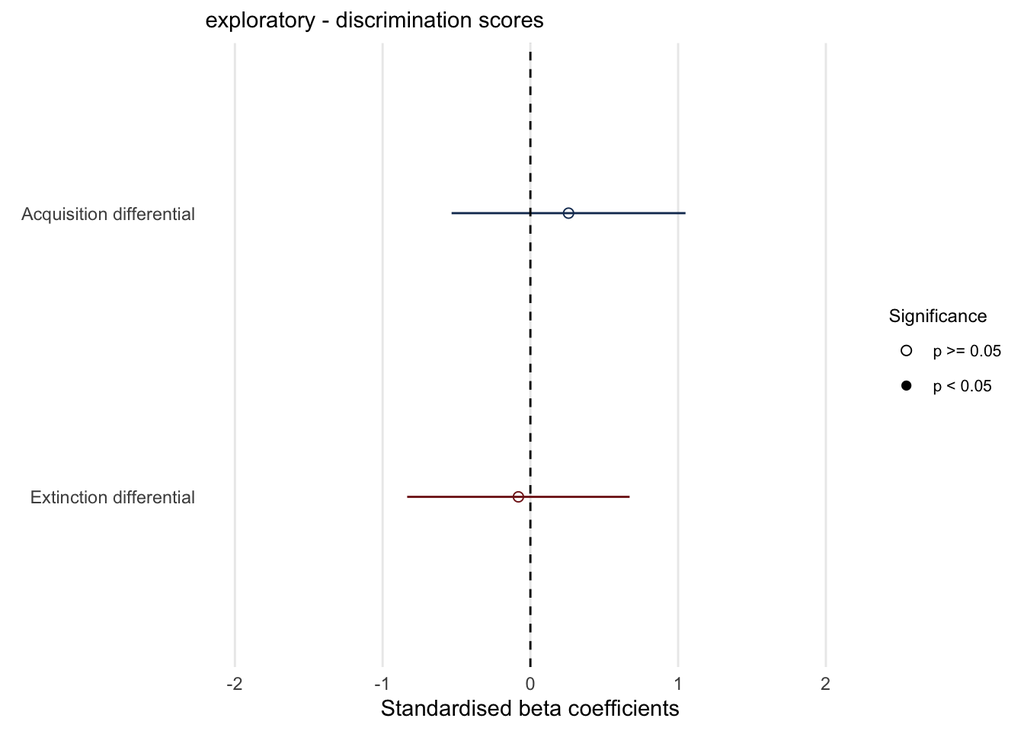

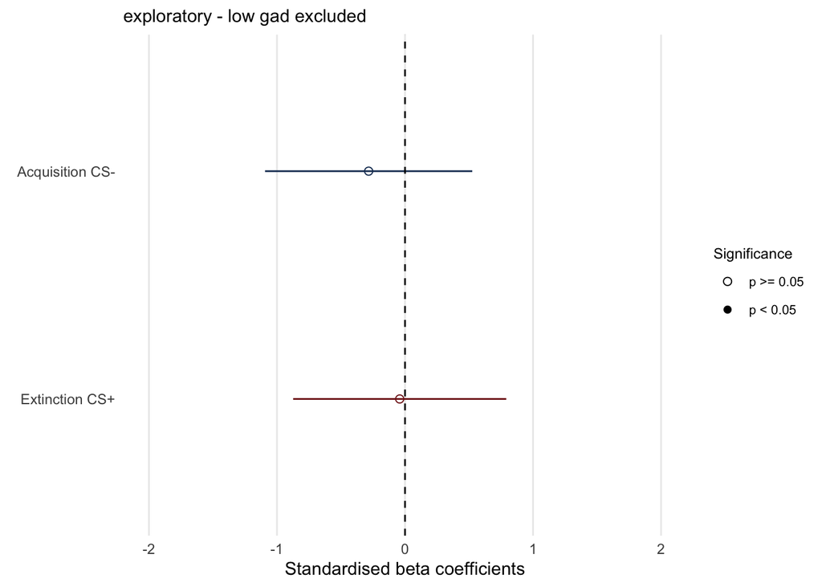

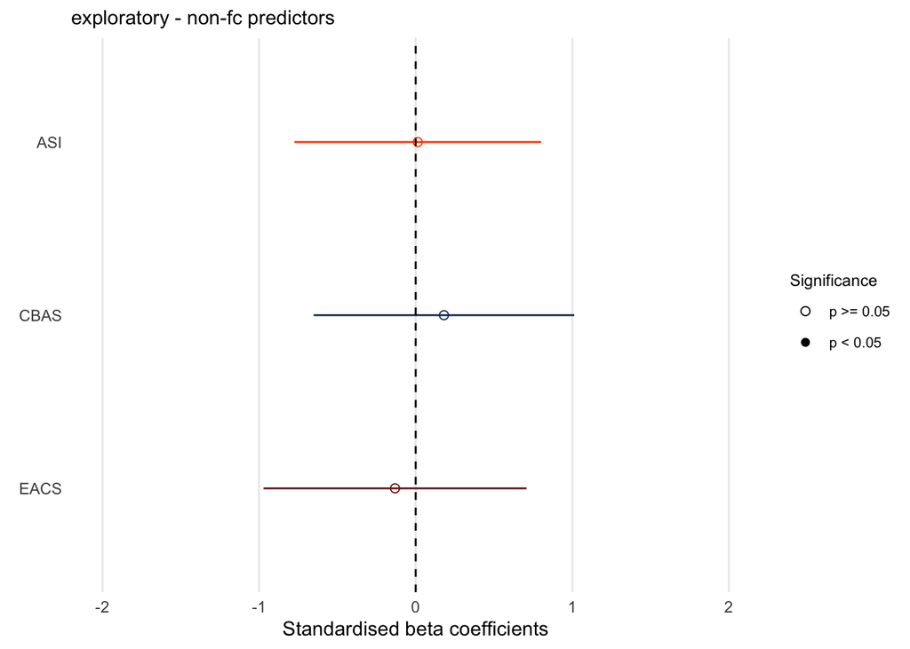

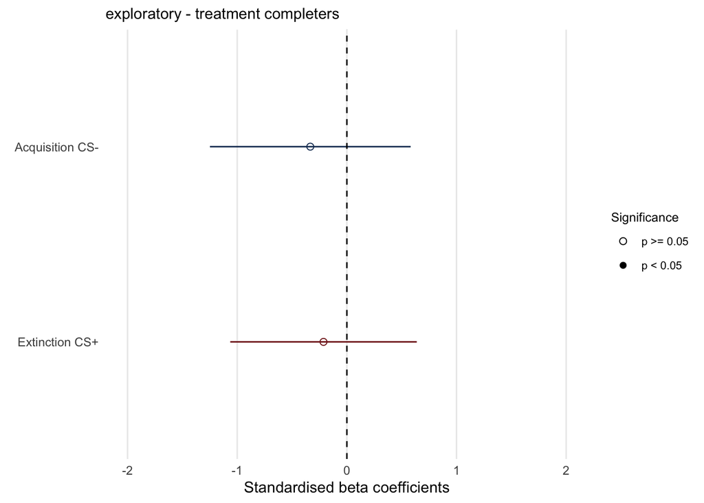

## Save tables

### Coefficients

#### All models

#### Separated by analysis type

Also converted to gt tables

##### Primary

| Term | Std. beta coefficient (Std. error) | 95% CIs | t | p-value (adjusted) |
| --- | --- | --- | --- | --- |
| Expectancy ratings - acquisition model |  |  |  |  |
| Intercept | 8.08 (0.38) | 7.33, 8.83 | 21.31 | <0.001 |
| Treatment sessions completed | -1.54 (0.38) | -2.3, -0.78 | -4.02 | <0.001 |
| Session 1 GAD-7 total | 2.53 (0.38) | 1.76, 3.29 | 6.56 | <0.001 |
| Acquisition CS- mean | -0.24 (0.38) | -1, 0.52 | -0.63 | 0.53 (1) |
| Expectancy ratings - extinction model |  |  |  |  |
| Intercept | 8.08 (0.38) | 7.33, 8.83 | 21.27 | <0.001 |
| Treatment sessions completed | -1.51 (0.39) | -2.28, -0.75 | -3.91 | <0.001 |
| Session 1 GAD-7 total | 2.5 (0.39) | 1.73, 3.26 | 6.47 | <0.001 |
| Extinction CS+ mean | 0.02 (0.38) | -0.74, 0.78 | 0.06 | 0.95 (1) |

##### Secondary

| Term | Std. beta coefficient (Std. error) | 95% CIs | t | p-value (adjusted) |
| --- | --- | --- | --- | --- |
| Age and sex adjustment - acquisition model |  |  |  |  |
| Intercept | 8.18 (0.4) | 7.39, 8.96 | 20.63 | <0.001 |
| Treatment sessions completed | -1.6 (0.38) | -2.36, -0.83 | -4.16 | <0.001 |
| Session 1 GAD-7 total | 2.44 (0.39) | 1.67, 3.21 | 6.31 | <0.001 |
| Sex assigned at birth | -0.97 (1.32) | -3.59, 1.65 | -0.73 | 0.465 |
| Age (years) | -0.58 (0.39) | -1.36, 0.19 | -1.50 | 0.138 |
| Acquisition CS- mean | -0.2 (0.38) | -0.95, 0.56 | -0.52 | 0.602 (1) |
| Age and sex adjustment - extinction model |  |  |  |  |
| Intercept | 8.18 (0.4) | 7.39, 8.97 | 20.60 | <0.001 |
| Treatment sessions completed | -1.57 (0.39) | -2.33, -0.8 | -4.06 | <0.001 |
| Session 1 GAD-7 total | 2.41 (0.39) | 1.64, 3.18 | 6.22 | <0.001 |
| Sex assigned at birth | -0.98 (1.32) | -3.6, 1.65 | -0.74 | 0.462 |
| Age (years) | -0.6 (0.39) | -1.37, 0.18 | -1.53 | 0.128 |
| Extinction CS+ mean | 0.05 (0.38) | -0.71, 0.81 | 0.13 | 0.896 (1) |
| FSS follow up (DV) - acquisition model |  |  |  |  |
| Intercept | 106.29 (1.84) | 102.64, 109.94 | 57.80 | <0.001 |
| Treatment sessions completed | -0.1 (1.86) | -3.8, 3.59 | -0.06 | 0.955 |
| FSS baseline total | 21.24 (2.01) | 17.25, 25.24 | 10.56 | <0.001 |
| Acquisition CS- mean | 0.81 (1.88) | -2.91, 4.54 | 0.43 | 0.666 (1) |
| FSS follow up (DV) - extinction model |  |  |  |  |
| Intercept | 106.3 (1.84) | 102.65, 109.95 | 57.78 | <0.001 |
| Treatment sessions completed | -0.1 (1.87) | -3.81, 3.62 | -0.05 | 0.959 |
| FSS baseline total | 21.29 (2.01) | 17.3, 25.27 | 10.60 | <0.001 |
| Extinction CS+ mean | 0.55 (1.86) | -3.14, 4.24 | 0.30 | 0.768 (1) |
| GAD-7 follow up (DV) - acquisition model |  |  |  |  |
| Intercept | 7.54 (0.41) | 6.74, 8.35 | 18.52 | <0.001 |
| Treatment sessions completed | -0.92 (0.41) | -1.73, -0.1 | -2.23 | 0.028 |
| Session 1 GAD-7 total | 2.53 (0.41) | 1.72, 3.35 | 6.16 | <0.001 |
| Acquisition CS- mean | -0.57 (0.42) | -1.4, 0.26 | -1.37 | 0.174 (1) |
| GAD-7 follow up (DV) - extinction model |  |  |  |  |
| Intercept | 7.54 (0.41) | 6.73, 8.35 | 18.44 | <0.001 |
| Treatment sessions completed | -0.93 (0.42) | -1.76, -0.11 | -2.24 | 0.027 |
| Session 1 GAD-7 total | 2.53 (0.41) | 1.71, 3.35 | 6.12 | <0.001 |
| Extinction CS+ mean | -0.45 (0.42) | -1.27, 0.38 | -1.07 | 0.285 (1) |

### Model fits

#### All models

#### Converted to gt table

| Model | R-squared (adjusted) | df | F | p-value | n |
| --- | --- | --- | --- | --- | --- |
| Primary |  |  |  |  |  |
| Expectancy ratings - acquisition CS- | 0.34 (0.32) | 3,105 | 18.09 | <0.001 | 109 |
| Expectancy ratings - extinction CS+ | 0.34 (0.32) | 3,105 | 17.89 | <0.001 | 109 |
| Secondary |  |  |  |  |  |
| Age and sex adjustment - acquisition CS- | 0.36 (0.33) | 5,103 | 11.57 | <0.001 | 109 |
| Age and sex adjustment - extinction CS+ | 0.36 (0.33) | 5,103 | 11.49 | <0.001 | 109 |
| GAD-7 follow-up (DV) - acquisition CS- | 0.29 (0.27) | 3,101 | 13.51 | <0.001 | 105 |
| GAD-7 follow-up (DV) - extinction CS+ | 0.28 (0.26) | 3,101 | 13.18 | <0.001 | 105 |
| FSS follow-up (DV) - acquisition CS- | 0.54 (0.53) | 3,100 | 39.25 | <0.001 | 104 |
| FSS follow-up (DV) - extinction CS+ | 0.54 (0.53) | 3,100 | 39.18 | <0.001 | 104 |

## Not pre-registered

### Percentage of extinction learning

Mean CR [(CS+) - (CS-)] of early extinction learning / mean CR [(CS+) - (CS-)] of last two trials of conditioning.

```
##    Min. 1st Qu.  Median    Mean 3rd Qu.    Max.    NA's
##    -Inf 0.09091 0.31111     NaN 0.57143     Inf       3
```

### Complete cases only

### Anxiety diagnoses only

### Exposure treatment only

# Visualisations

## Elephant

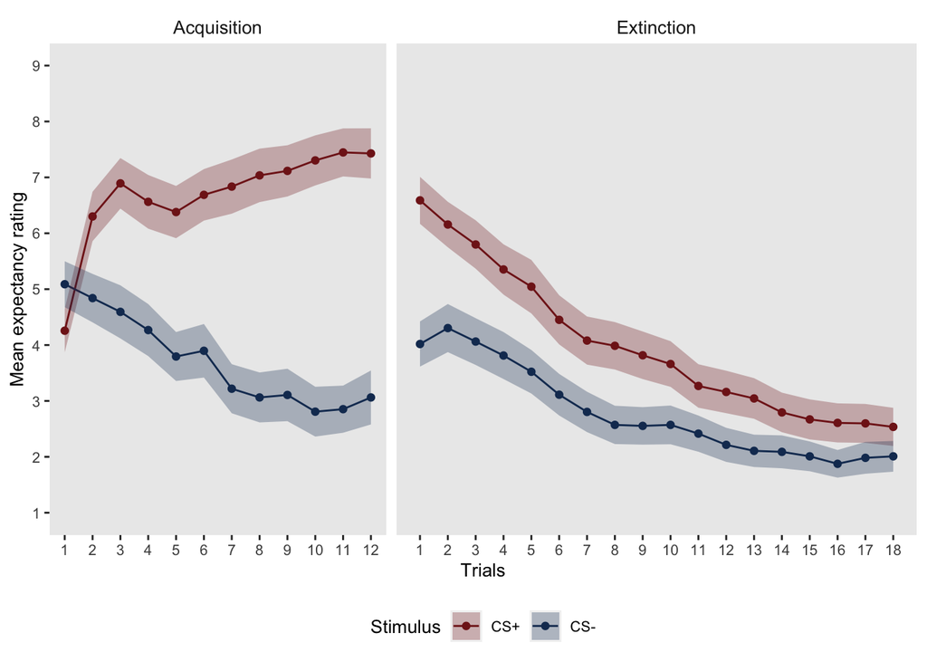